# Final_Capstone slides

## Final Capstone: Text Classification of Wine Reviews with NLP

by Doug Johnson

#### Problem trying to address:

Generation Z isn’t drinking wine at the same growth rate as prior generations. As a result the wine industry is experiencing a demand shortage during a time where quantity of grapes in cultivation has increased. Price pressure is forecasted due to these circumstances, in certain segments. Without an increase in demand, or reducing grape acreage under cultivation, the wine industry could see a reduction in profit margins. Surveys show Generation Z finds the wine market hard to understand and wants online advertising, online education, and an online application to help navigate product.

#### Project Statement:

Create application which can identify quality of a wine based on text reviews using NLP to:

- Suggest wines similar to flavor preferences.
- Suggest varietals similar to known preferred varietal.
- Suggest different varietals with similar ratings in similar region.
- Suggest wines that appear to be values, or if desired, best-of-breed or prestigious.

#### Feature of primary interest: 'description'.

NLP - Will utilize the 'description' feature which is a review for a given wine. Using the text from the review, will use TF-IDF and Word2Vec in both supervised and unsupervised learning, including topic extraction.

#### Target Variable

point_rank:

> categorical: '0','1'  
> 0 -> Premium Super Segment  
> 1 -> Luxury Super Segment

#### Milestones:

Step 1: Load data.  
Step 2: Clean data.  
Step 3: Explore data. Price and numeric rating first, then the text review('description').  
Step 4: NLP, TF-IDF and Word2Vec including topic modeling.  
Step 5: Test classification prediction using text and numeric features with multiple models.  
Step 6: Application prototype.  
Step 7: Summary.

### Variable of significance

Each row contains a review and information for a bottle of wine. The review is named 'description'.

Sample highest point rating review:  
2145 Full of ripe fruit, opulent and concentrated, this is a fabulous and impressive wine. It has a beautiful line of acidity balanced with ripe fruits. The wood aging is subtle, just a hint of smokiness and toast. This is one of those wines, from a great white wine vintage, that will age many years. Drink from 2024.

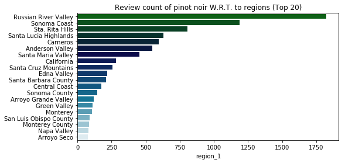

```python
# 20 MOST REVIEWED REGIONS FOR PINOT NOIR IN CA
plt.figure(figsize=(8,4))
cnt = df[(df['country'] == 'US') &
         (df['province'] =='California') &
         (df['variety'] == 'Pinot Noir')]['region_1'].value_counts().to_frame()[0:20]
sns.barplot(x= cnt['region_1'], y =cnt.index, data=cnt, palette='ocean',orient='h')
plt.title('Review count of pinot noir W.R.T. to regions (Top 20)');
```

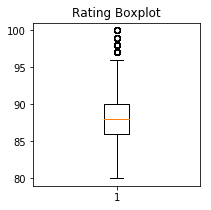

```python
# BOXPLOT
plt.figure(figsize=(3,3))
plt.boxplot(df['points'],whis=1.5)
plt.title('Rating Boxplot')
plt.show()
```

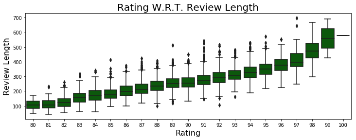

```python
plt.figure(figsize=(12,4))
prc_bp = sns.boxplot(x='points', y='desc_length', data=df_pn20_prc,
                color='darkgreen')
prc_bp.set_title('Rating W.R.T. Review Length', fontsize=20)
prc_bp.set_ylabel('Review Length', fontsize = 16) # Y label
prc_bp.set_xlabel('Rating', fontsize = 16) # X label
plt.show()
```

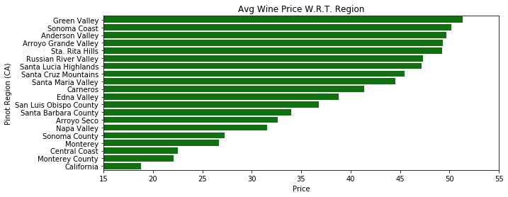

```python
cnt = df_pn20_prc.groupby(['region_1']).mean()['price'].sort_values(ascending=False).to_frame()[0:20]
fig,ax = plt.subplots(figsize=(10,4))
sns.barplot(x= cnt['price'], y=cnt.index, data=cnt, color='green', orient='h')#palette='ocean',)
ax.set(xlim=(15, 55))
ax.set(title='Avg Wine Price W.R.T. Region')
ax.set(xlabel='Price')
ax.set(ylabel='Pinot Region (CA)');
```

### Wine market segmentation

Generally speaking the wine market is broken up into segments based on price. There are certainly customer demographics that are important to the wine industry, but for this project we don't have access to that data.

Price segmentation.

Some have grouped the wine market into three general categories (super segments). Note this is for all varietals. These segments are:

- Everyday (in an efficient market, lower price, lower rating)
- Premium
- Luxury (in an efficient market, higher price, higher rating)

This project chose two categories to classify, premium and luxury.

- 0: Premium
- 1: Luxury in an efficient market, higher price, higher rating)

Here is the reasoning. Pinot noir has a thin skin, and the yield per acre, particularly for high end pinot (drop fruit for concentration), is significantly lower than, Cabernet Sauvignon for example. Moreover pinot is more susceptiable to adverse weather variables such as temperature and moisture. This increases cost of production. For the most part, pinot noir has a higher cost of production and thus not used as frequently for mass market bottlings at an "everyday" price point (think box wines and bottles < $7). Certainly there are lower price point pinot's, but on the whole, pinot, particularly in the reviews in this dataset (bias will be addressed in summary), is not frequently reviewed, in the "everyday" segment.

To conclude, two super segment categories will be used to classify the pinot reviews as actual point predictions would be nuanced, possibly overfitted, and likely not generalize well.

#### Target variable

As review observations appear to group well into two segments and we will assign two classification targets:  
0: Premium which is 90 points and below.  
1: Luxury which is 91 points and above.

Values in each category:

> 0: Premium = 4560  
> 1: Luxury = 3453

```python
# NUMERIC CORRELATION BETWEEN POINTS AND STANDARDIZED PRICE AND DESCRIPTION LENGTH
corr=df_pn20_prc[['points','prc_bc','desc_len_bc']].corr()
corr.style.background_gradient(cmap = 'coolwarm')
```

|  | points | prc_bc | desc_len_bc |
| --- | --- | --- | --- |
| points | 1 | 0.577789 | 0.73926 |
| prc_bc | 0.577789 | 1 | 0.45348 |
| desc_len_bc | 0.73926 | 0.45348 | 1 |

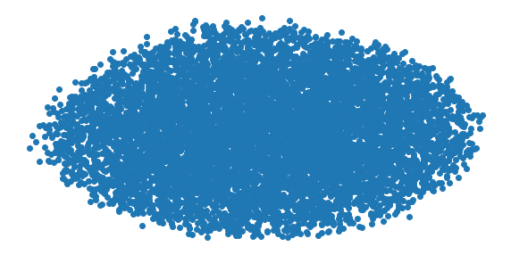

```python
# UMAP
X = df_pn20_prc[['desc_len_bc', 'price']]
X.values

umap_results = umap.UMAP(n_neighbors=20, min_dist=1,
                         metric='correlation').fit_transform(X)

plt.figure(figsize=(10,5))
plt.scatter(umap_results[:, 0], umap_results[:, 1])
plt.xticks([])
plt.yticks([])
plt.axis('off')
plt.show()
```

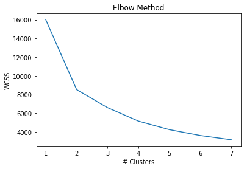

```python
# DETERMINE OPTIMAL CLUSTER NUMBER
# ELBOW METHOD -> WITHIN CLUSTER SUM OF SQUARES (WCSS)
wcss = []
for i in range(1,8):
    kmeans = KMeans(n_clusters = i, init = 'random', max_iter = 300,
                    n_init = 10, random_state = 42)
    kmeans.fit(df_pn20_prc[['desc_len_bc','prc_bc']])
    wcss.append(kmeans.inertia_)
plt.plot(range(1,8), wcss)
plt.title('Elbow Method')
plt.xlabel('# Clusters')
plt.ylabel('WCSS')
plt.show()
```

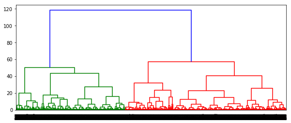

```python
# AGGLOMERATIVE CLUSTERING
plt.figure(figsize=(10,4))
dendrogram(linkage(df_pn20_prc[['desc_len_bc','prc_bc']], method='ward'))
plt.show()
```

#### Analysis

Appears price and description length hold most of the predictive power.

##### Price and description length: 80%

mean=0.80 std=(+/- 0.02) all=[0.80456758 0.80643954 0.77948334]

##### Regions: 61%

mean=0.61 std=(+/- 0.03) all=[0.58554848 0.60913516 0.62560839]

##### Price, description length and regions: 80%

mean=0.80 std=(+/- 0.03) all=[0.80718832 0.81505054 0.7768626 ]

## Step 4: NLP, TF-IDF and Word2Vec including topic modeling.

#### Create a stopwords variable and preprocess.

Adding a custom list of stopwords to use in conjunction with the default 'STOPWORDS' from Genism. Results of custom list were better than default. Did initial benchmark tests to determine which method performed better.

#### Preprocessing functions: Lemmantize and stem

Lemmantize -> Intended part of speech (POS) for meaning of word in sentence  
Stemming -> Reduce word to root form  
Standardize tense -> Verb tenses to present, third and second person to first person  
Punctuation -> Remove all  
Lower case -> Words to lower case  
Tokenize -> Split review to process on a word level  
Character filter -> Ignore small words, words < three characters ignored  
Stopwords -> Ignore common words that are frequent and perceived as low value

```python
#ANALYZE IMPACT OF PREPROCESSING
print(df_pn20_prc['description'].head(1))
print()
print(df_pn20_prc['clean_desc'].head(1))
```

```
0    The producer sources from two blocks of the vineyard for this wine—one at a high elevation, which contributes bright acidity. Crunchy cranberry, pomegranate and orange peel flavors surround silky, succulent layers of texture that present as fleshy fruit. That delicately lush flavor has consider…
Name: description, dtype: object

0    produc sourc block high elev contribut bright acid crunchi cranberri pomegran orang flavor surround silki succul layer textur present fleshi delic lush consider length
Name: clean_desc, dtype: object
```

#### TF-IDF

- ngram = 1, meaning no bi-grams or tri-grams, ie multiple words as one feature such as "pinot noir" or "cherry cola".
- Word level
- minimum document frequency of .01.

Term Frequence = Number times document appears in a documents. Inverse Document Frequence = log((total number of documents)/(number documents with term))

TF-IDF = TF x IDF

```python
# USE THIS TO GET tfidf_ngram INTO DATAFRAME VS CSR MATRIX
# GO FROM SPARSE TO DENSE. SPARSE IS OPTIMIZED MATRIX FOR LOOKUP.
dense = tfidf_ngram.todense()
denselist = dense.tolist()

# CONVERT LIST TO DATAFRAME, RENAME
df_tfidf_ngram_wine = pd.DataFrame(denselist, columns=tfidf_ngram_feat)
df_tfidf_ngram_wine.head(1)
```

|  | age | ageabl | ager | appeal | appel | approach | balanc | beauti | best | better | ... | tough | unrip | veget | velveti | vibrant | wave | young | youth | zest | zesti |
| --- | --- | --- | --- | --- | --- | --- | --- | --- | --- | --- | --- | --- | --- | --- | --- | --- | --- | --- | --- | --- | --- |
| 0 | 0.0 | 0.0 | 0.0 | 0.0 | 0.0 | 0.0 | 0.0 | 0.0 | 0.0 | 0.0 | ... | 0.0 | 0.0 | 0.0 | 0.0 | 0.0 | 0.0 | 0.0 | 0.0 | 0.0 | 0.0 |

1 rows × 155 columns

#### Analysis:

PCA on TD-IDF word features only.

Mean accuracy changes from run to run.

Defaut Genism STOPWORD TF-IDF  
229 NLP Principal Components to explain 80% of the dataset.  
mean=0.77 std=(+/- 0.06) all=[0.7768626 0.80868589 0.72968925]

Modified stopwords with Genism STOPWORD TF-IDF  
90 NLP Principal Components to explain 80% of the dataset.  
mean=0.80 std=(+/- 0.03) all=[0.80756271 0.81467615 0.77723699]

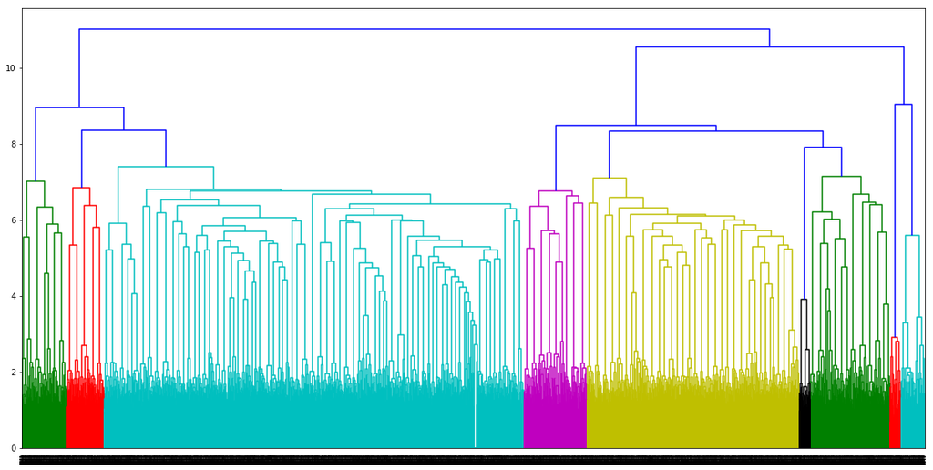

```python
# AGGLOMERATIVE CLUSTERING
plt.figure(figsize=(20,10))
dendrogram(linkage(X, method='ward'))
plt.show()

# UNSTABLE CLUSTERING RESULT
```

#### Topic modeling - TF-IDF scores with LSA, LDA and NNMF

2 Topics 10 Top Words

LSA topic modeling. The core idea is to take a matrix of what we have — documents and terms — and decompose it into a separate document-topic matrix and a topic-term matrix. Can use TF or TF-IDF

SVD dimensionality reduction can be performed using truncated SVD. SVD, or singular value decomposition, is a technique in linear algebra that factorizes any matrix M into the product of 3 separate matrices: M=U*S*V, where S is a diagonal matrix of the singular values of M. Critically, truncated SVD reduces dimensionality by selecting only the t largest singular values, and only keeping the first t columns of U and V.

-LSA - large dataset required, don't know topics, components can be arbitraritly pos or neg

PLSA is probabilistic versioin of LSA. PLSA requires a fixed "document" in dataset. If don't have, can't predict. A document that contains a topic will have a high probability of containing some words (related to the topic), and a low probability of containing other words (unrelated to the topic). Documents also have a probability of featuring each topic, low for some topics and high for others.

LDA Topic modeling. Baysian version of PLSA. Looking at most probable distribution given existing distribution. Generalizes better than PLSA. Trains on set and can predict without using a specific document.

NNMF - Non negative matrix factorization. Matrix multiplication with no negative numbers. Optimize using gradient descent.

```python
for topic in range(ntopics):
    print('Topic {}:'.format(topic))
    print(topwords.loc[topic][0:40])
```

```
Topic 0:
               LSA              LDA            NNMF
0  rich 419.75      silki 321.6      rich 25.96
0  silki 379.93     rich 258.85      tannin 25.0
0  tannin 379.42    tannin 238.52    finish 24.48
0  ripe 361.09      ripe 223.71      ripe 23.2
0  finish 355.9     sweet 212.39     bodi 22.48
0  complex 332.8    good 211.97      soft 16.66
0  textur 330.88    complex 204.74   complex 16.64
0  bodi 313.9       textur 204.0     sweet 15.97
0  sweet 309.9      eleg 184.26      earthi 14.73
0  soft 297.19      crisp 180.75     textur 13.94
0  good 268.05      finish 175.03    balanc 13.49
0  tart 256.68      tart 164.09      tart 12.96
0  eleg 250.63      delici 156.0     delici 11.24
```

[output cut: 29 more lines]

### Word2Vec

For a word W, it looks at the words that are near W in the sentence, and shifts the values in the word vectors such that the vectors for words near that W are closer to the W vector, and vectors for words not near W are farther away from the W vector.

With a large enough corpus, this will eventually result in words that often appear together having vectors that are near one another, and words that rarely or never appear together having vectors that are far away from each other.

Then, using the vectors, similarity scores can be computed for each pair of words by taking the cosine of the vectors.

```python
# Word2Vec WORD SIMILARITIES
w1 = "green"
model.wv.most_similar(positive=w1, topn=7)
```

```
[('unrip', 0.9066093564033508),
 ('veget', 0.8872575163841248),
 ('minti', 0.8671924471855164),
 ('veggi', 0.8546618819236755),
 ('edg', 0.851651132106781),
 ('stalki', 0.8401265144348145),
 ('sharp', 0.8388955593109131)]
```

```python
w1 = ["love",'complex','eleg']
w2 = ['green']
model.wv.most_similar (positive=w1,negative=w2,topn=10)
```

```
[('beauti', 0.9541754722595215),
 ('refin', 0.8863215446472168),
 ('gorgeous', 0.8659319877624512),
 ('perfect', 0.8481670618057251),
 ('wonder', 0.8206522464752197),
 ('intric', 0.7958523035049438),
 ('pure', 0.7823735475540161),
 ('absolut', 0.7808597087860107),
 ('terrif', 0.7578171491622925),
 ('upscal', 0.757124662399292)]
```

```python
# Word2Vec USING WORD AVERAGING
# FIVE PRINCIPAL COMPONENTS VS 90 FOR TD-IDF TO EXPLAIN 80%
pca = PCA(n_components = 5)
logreg = LogisticRegression(solver='lbfgs',max_iter=50000)
pipeline = Pipeline([('pca', pca), ('logistic', logreg)])
score_fs_pca = cross_val_score(pipeline, X_word_average, y, scoring="accuracy", cv=3)
print("mean={:.2f}   std=(+/- {:.2f})   all={} ".format(score_fs_pca.mean(),
                                                        score_fs_pca.std()*2, score_fs_pca))
```

```
mean=0.75   std=(+/- 0.08)   all=[0.7588918  0.78659678 0.69150131]
```

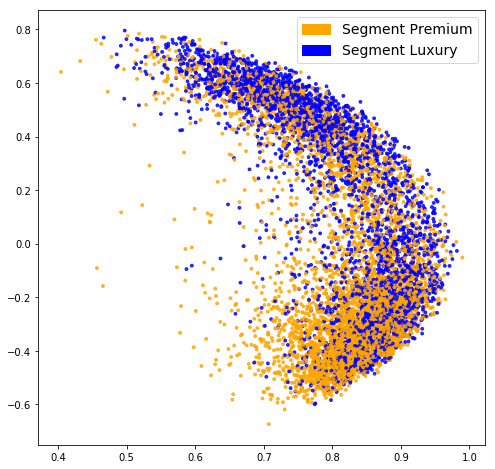

```python
# TOPIC MODELING Word2Vec
fig = plt.figure(figsize=(8, 8))
plot_LSA(X_word_average, y)
plt.show()
```

## Step 5: Text Classification with Logistic Regression, Random Forest and SVM

30 PCA components to explain 80% Using price, description length, regions, and TD-IDF scores

```python
df_pn20_prc.iloc[:,30:40].columns
```

```
Index(['region_1_Santa Lucia Highlands', 'region_1_Santa Maria Valley',
       'region_1_Sonoma Coast', 'region_1_Sonoma County',
       'region_1_Sta. Rita Hills', 'point_rank', 'prc_bc', 'desc_len_bc',
       'clean_desc', 'age'],
      dtype='object')
```

### All features, TF-IDF, regions, price, description length

> Logistic Regression LR Accuracy Best Paramaters GridSearchCV: Principal Component Analysis: 0.82

> Random Forest RFC Accuracy Best Paramaters GridSearchCV: Principal Component Analysis: 0.80

> Support Vector Machine SVM Accuracy Best Paramaters GridSearchCV: Principal Component Analysis: 0.81

### Benchmarking for reference

> Price and description length: 80%  
> mean=0.80 std=(+/- 0.02) all=[0.80456758 0.80643954 0.77948334]

> Regions: 61%  
> mean=0.61 std=(+/- 0.03) all=[0.58554848 0.60913516 0.62560839]

> Price, description length and regions: 80%  
> mean=0.80 std=(+/- 0.03) all=[0.80718832 0.81505054 0.7768626 ]

> Word2Vec - PCA (80% = 5 PCs)  
> mean=0.74 std=(+/- 0.08) all=[0.75589667 0.78921752 0.68813179]

#### CONFUSION MATRIX

Null hypothesis: Not different (predict class 0 ... is same or different)x-axis predicted, y-axis actual.  
y-axis, no diff on top, diff below  
x-axis, no diff to left, diff to right

Confusion matrix  
TP FP  
FN TN

Type I (FP) errors. False Alarm. Actual satisfies the null hypothesis but the test rejects the null hypothesis. Type II (FN) errors. Actual does not satisfy the null hypothesis but the test accepts the null hypothesis.

Recall = TP / (TP + FN)  
Precision = TP / (TP + FP)  
accuracy = 0.8291, precision = 0.8290, recall = 0.8291, f1 = 0.8290

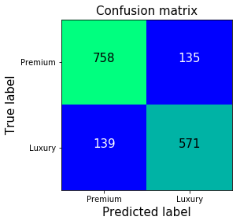

## Step 6: Application for Generation Z

App will have inputs from user, such as variety (ex. pinot noir), winery (ex. Peay Vineyards), region (ex. Sonoma Coast), country (ex. US) characteristics of wine they prefer (ex. minerality, medium acid, complex, integrated, long length, floral), price (ex. <40), segment (ex. Luxury), point rating min (ex. >=90), or perceived rating through text analysis (ex. Luxury).

Can take inputs and filter the input dataframe and results using TF-IDF. See example below.

For example, select for pinot noir, and ask the app for suggestions of other pinot noir wines that are 90 points or greater, and produced in the US.The app will "train" the dataset by marking all pinot noir reviews 96 points or greater as wines the user likes. Note, diff than minimum of 90 for suggestion. Can also add filters such as price, for example, less than $40.

Can also look for similar varietals in similar regions with similar ratings, or even have different varietals in diff regions with smilar ratings, but diff varietal or same varietal.

```python
wine_var_list = ['Syrah', 'Zinfandel']
df_wine = df.copy()
df_wine = df_wine[(df_wine['points'] >=90) &
                  (df_wine['country'] == 'US') &
                  (df_wine['variety'].isin(wine_var_list))]
df_wine.shape
```

```
(3307, 13)
```

```python
# OUTPUT RESULTS
tfidf_recs[tfidf_recs['price'] < 40].drop(columns='description')
```

|  | country | designation | points | price | province | region_1 | region_2 | variety | winery | taster_name | taster_twitter_handle | title | user_pref |
| --- | --- | --- | --- | --- | --- | --- | --- | --- | --- | --- | --- | --- | --- |
| 207 | US | Home Ranch Teldeschi Vineyards Century Old Vine | 90 | 32.0 | California | Dry Creek Valley | Sonoma | Zinfandel | Del Carlo Winery | Virginie Boone | @vboone | Del Carlo Winery 2014 Home Ranch Teldeschi Vineyards Century Old Vine Zinfandel (Dry Creek Valley) | 0 |
| 2898 | US | Flight | 91 | 38.0 | California | Dry Creek Valley | Sonoma | Zinfandel | Quivira | NaN | NaN | NaN | 0 |
| 1885 | US | Old Vine | 91 | 30.0 | California | Dry Creek Valley | Sonoma | Zinfandel | Dry Creek Vineyard | NaN | NaN | NaN | 0 |
| 2332 | US | Estate Vineyards | 90 | 36.0 | California | Napa Valley | Napa | Syrah | Burgess | NaN | NaN | NaN | 0 |
| 2227 | US | Sherman Family Vineyard Old Vine | 90 | 24.0 | California | Lodi | Central Valley | Zinfandel | Fields Family | NaN | NaN | NaN | 0 |
| 65 | US | Estate Select | 91 | 36.0 | California | Santa Clara Valley | Central Coast | Syrah | Jason-Stephens | NaN | NaN | NaN | 0 |

## Step 7: Summary

#### Q: Why I chose this project.

This project is an exploration f the NLP specialization. The project covers many of the common and advanced NLP uses and extends it to cosine similarities and recommendation. I wanted to stretch myself and do an in-depth review of NLP.

#### Q: Why it works.

The TF-IDF recommendation engine can be extended to perform a number of tasks for a number of users types, meaning both supply and demand side of the wine industry.

#### Q: What problem is solved.

Education and suggestions to those overwhelmed by choosing a wine and whom prefer an app based interface. Business side can also utilize this type of tool to perform basic segmentation analysis as well as pricing research.

#### Q: How it will run in a production like environment.

This type of model will be an ensemble model. As wine differs from region to region, and variety to variety, so will the reviews. Best to compare apples to apples and create a collection of ensemble models specializing in topic areas. There will be a GUI for this application so users can easily select preferences and filters, as well as have a nice presentation of information.

#### Q: What would you need to do to maintain it going forward?

As years come and go, collect reviews, update the dataset, and retrain the models and stopwords on the new data.

#### Q: A specified research question your model addresses.

Project educates and recommends product to the consumer.

#### Q: How you chose your model specification and what alternatives you compared it to.

Chose model based on benchmarking and comparing different scores like Word2Vec and TF-IDF. Also compared different clustering methods, topic modeling methods, and different classification algorithms for predicting class.

#### Q: The visuals you chose and what they represent for your research.

Used scatter, boxplot, histogram, and bar to visualize density, variance, outliers, and trend in data.

#### Your end-user and the value your project provides to them.

End user is Generation Z or any group interested in wine and looking for suggestion of varietals, wines, or valuation relative to others in a region, rating class, or price point.

#### The practical uses of your model for an audience of interest.

Identify quality wine at a reasonable price. Get suggestion for unique varietals from different regions or countries. Determine if wine is over rated/underrated, overvalued/undervalued.

#### Potential problems, weak points or shortcomings of your model.

- Availiability of reviews: Ideally would have a list of all wineries and retail pricing with accurate descriptions, meaning descriptions that have structure and are similar.
- Comparability: Descriptions are not structured, and the high end wines get a more complete review. Doesn't lend to comparison. For example, a review should likly speak to alcohol levels, structure, complexity, body, length, smell, and flavor characteristics including varietal specific, region specific, barrel influence, and secondary as well as terciary characteristics.
- Taste and valued features of wine are subjective.
- Stopwords, or words of little value with respect to wine reviews are more nuanced and need consideration to have quality generalized performance. Consider using preset vocabulary versus training and scoring a vocabulary.
- Word averaging with Word2Vec doesn't seem to be the best approach for similar document analysis.

#### Bias

> Selection Bias:
> - High rating/price. Wine enthusiast targeting higher end wines, which generally have higher ratings and price.
> - Regions. The regions of US, California, and varietal of Pinot Noir receive the most reviews. Note there is a bias in this dataset to Russian River Valley and the Sonoma Coast as they are have significantly more reviews than the majority of other regions. This should not impact project and is more a statement on the primary regions for Premium and Luxury pinot noir production.
> - Sentiment: Reviews are more positive or neutral as oppessed to negative. Believe this is due to industry influence and target market, as well as selection.

#### Additional research proposal

- Take an ensemble approach. Train a series of models based on variety and region so can have accurate, apples-to-apples NLP text processing.
- Develop the application to do business side segmentation. Know if undervalued or overvalued for region and varietal.
- Compute life time value of customer.
- Use demographic data to segment data.
- Use PLSA for topic modeling. More appropriate given example at end and how approaching.
- Dictionary documents specific to desired topics using vocabulary in TF-IDF.
- Use Word2Vec without word averaging.